# R Notebook

Here I am going to make a pipeline to replicate some of the findings reported in https://www.tandfonline.com/doi/full/10.1080/19490976.2020.1747329#d1e1343.

# 16S Data Analysis

I will start with the author’s provided OTU table. We had wanted to re-process all of their raw 16S data using DADA2, but the files they have uploaded to SRA seem to have already been merged, and DADA2 can not interpret merged reads. Instead, we will have to use the provided OTU table provided on Kaggle (https://www.kaggle.com/datasets/antaresnyc/human-gut-microbiome-with-asd/data/discussion?select=GSE113690_Autism_16S_rRNA_OTU_assignment_and_abundance.csv)

I am going to use different tools/processing than the authors used in many cases and we will see if the results I obtain look similar.

Ultimately, I want to generate key figures that we can also generate using metagenomic data for comparison purposes.

```r
library(ggpubr)
library(phyloseq)
library(ggplot2)
library(tidyr)
library(dplyr)
library(MiscMetabar)
library(ggVennDiagram)
library(tidyverse)
library(tibble)
library(breakaway)
```

```r
#Create Phyloseq Object
otu_table_data <- read.csv("/Users/cmdb/qb25-answers/DADA2_Subset_Attempt1_files/OTU_Table.csv", row.names = 1)
metadata_table_data <- read.csv("/Users/cmdb/qb25-answers/DADA2_Subset_Attempt1_files/Metadata_Table.csv", row.names = 1)
tax_table_data <- read.csv("/Users/cmdb/qb25-answers/DADA2_Subset_Attempt1_files/OTU_Taxonomy_Table.csv", row.names = 1)

PS <- phyloseq(
  otu_table(as.matrix(otu_table_data), taxa_are_rows = TRUE),
  sample_data(metadata_table_data),
  tax_table(as.matrix(tax_table_data)))
```

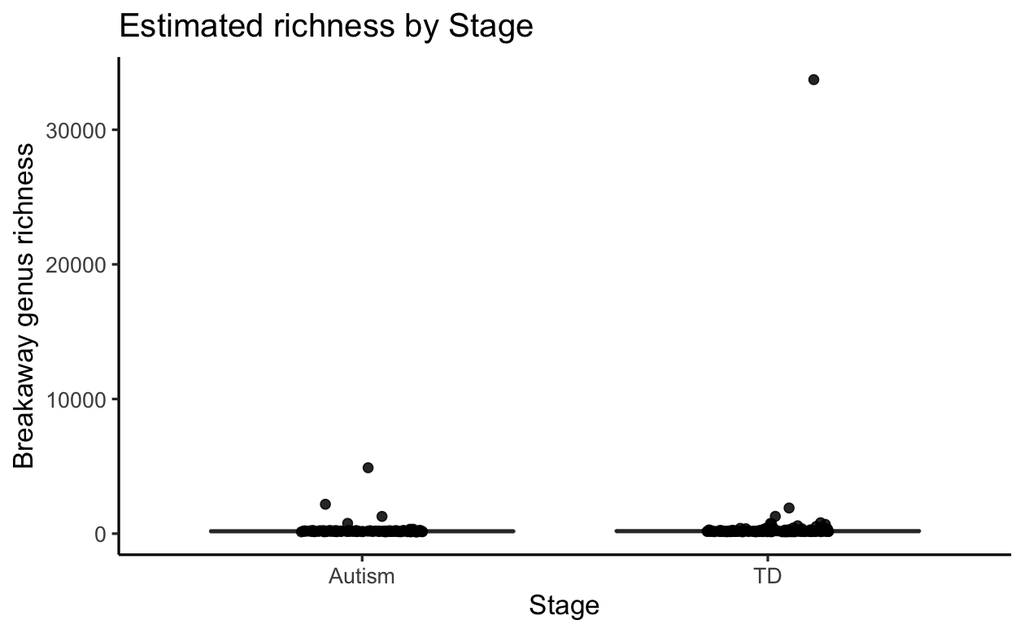

```r
#They claim to use the BreakAway package to estimate species richness
PS_genus <- tax_glom(PS, taxrank = "Genus")
PS_phylum <- tax_glom(PS, taxrank = "Phylum")
estimated_richness1 <- breakaway(PS_genus)

# ChatGPT gave me this step to convert the breakaway output to a tibble so I can left_join my sample data so I can color by Stage
richness_df <- tibble(
  sample_id = names(estimated_richness1),
  estimate  = vapply(estimated_richness1, function(x) x$estimate, numeric(1)),
  error     = vapply(estimated_richness1, function(x) if (!is.null(x$error)) x$error else NA_real_, numeric(1)),
  lower     = vapply(estimated_richness1, function(x) if (!is.null(x$interval)) x$interval[1] else NA_real_, numeric(1)),
  upper     = vapply(estimated_richness1, function(x) if (!is.null(x$interval)) x$interval[2] else NA_real_, numeric(1)),
  method    = vapply(estimated_richness1, function(x) if (!is.null(x$name)) x$name else NA_character_, character(1))
)

sdat <- phyloseq::sample_data(PS_genus) %>%
  as("data.frame") %>%
  rownames_to_column("sample_id") %>%
  select(sample_id, Stage)

richness_df <- left_join(richness_df, sdat, by = "sample_id")

# Plot
ggplot(richness_df, aes(x = Stage, y = estimate, fill = Stage)) +
  geom_boxplot(alpha = 0.35, outlier.shape = NA) +
  geom_jitter(width = 0.15, size = 2, alpha = 0.85) +
  labs(x = "Stage", y = "Breakaway genus richness", title = "Estimated richness by Stage") +
  theme_classic(base_size = 14) +
  theme(legend.position = "none")
```

There seems to be a huge outlier. Let me take a look at that…

```r
richness_df <- richness_df %>%
  mutate(rel_error = error / estimate)
richness_df %>% arrange(desc(estimate)) %>% head()
```

| sample_id | estimate | error | lower | upper | method | Stage | rel_error |
| --- | --- | --- | --- | --- | --- | --- | --- |
| A165 | 33721.579 | 32529321.239 | 137.1930 | 514399763 | breakaway | TD | 964.644073 |
| B45 | 4893.219 | 1926038.056 | 125.6713 | 33868469 | breakaway | Autism | 393.613708 |
| B125 | 2181.636 | 41918.837 | 138.4592 | 2865161 | breakaway | Autism | 19.214405 |
| A125 | 1903.845 | 27395.837 | 135.5270 | 2051480 | breakaway | TD | 14.389744 |
| A66 | 1283.788 | 17368.385 | 134.1332 | 1168787 | breakaway | TD | 13.529017 |
| B51 | 1278.121 | 8291.915 | 130.7270 | 764754 | breakaway | Autism | 6.487585 |

```r
richness_df %>% arrange(desc(rel_error)) %>% head()
```

| sample_id | estimate | error | lower | upper | method | Stage | rel_error |
| --- | --- | --- | --- | --- | --- | --- | --- |
| A165 | 33721.579 | 32529321.239 | 137.1930 | 514399763.5 | breakaway | TD | 964.644073 |
| B45 | 4893.219 | 1926038.056 | 125.6713 | 33868469.3 | breakaway | Autism | 393.613708 |
| B125 | 2181.636 | 41918.837 | 138.4592 | 2865160.8 | breakaway | Autism | 19.214405 |
| A125 | 1903.845 | 27395.837 | 135.5270 | 2051480.1 | breakaway | TD | 14.389744 |
| A66 | 1283.788 | 17368.385 | 134.1332 | 1168787.3 | breakaway | TD | 13.529017 |
| A7 | 726.478 | 6784.293 | 126.8391 | 429848.3 | breakaway | TD | 9.338608 |

This does not look right at all. I think what is happening is that the table I have from the authors has already been rarefied (all total counts acorss samples are equal)

```r
head(colSums(otu_table(PS)))
```

```
   A1   A10  A100  A101  A102  A104
31757 31757 31757 31757 31757 31757
```

All samples have 31757 reads. I am pretty sure that rarefying does this (makes all total counts equal to each other). I researched it and I do not think Breakaway can work on already rarefied data. So either the authors did this breakaway analysis and then rarefied, and then only uploaded the rareified data - or - they did not actually use the breakaway package.

Instead I will do some orthogonal analyses using different tools. Here I will use the built in shannon diversity and simpsom diversity measurements from the Phyloseq package.

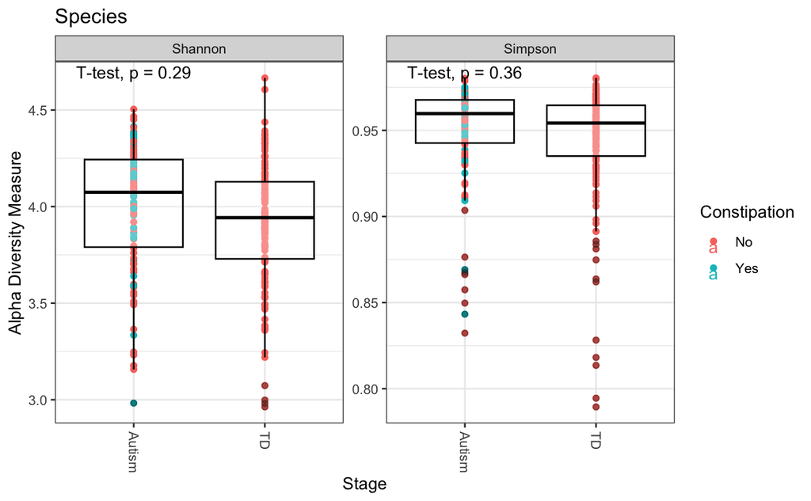

```r
theme_set(theme_bw())
plot_richness(PS, x="Stage", measures=c("Shannon", "Simpson"), color="Constipation") +
  geom_boxplot(alpha = 0.3, color = "black") +
  stat_compare_means(method = "t.test") + #ADD STATS
  theme(legend.position="right") +
  labs(title = "Species")
```

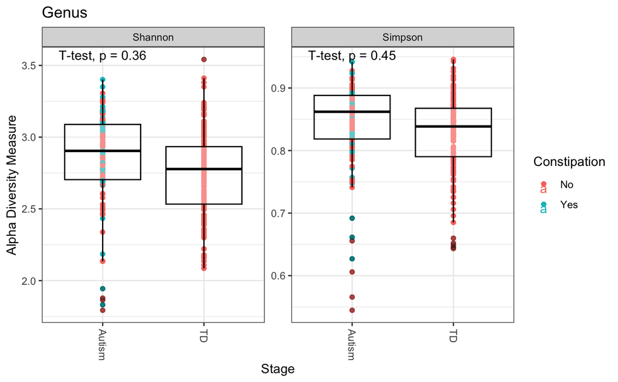

```r
plot_richness(PS_genus, x="Stage", measures=c("Shannon", "Simpson"), color="Constipation") +
  geom_boxplot(alpha = 0.3, color = "black") +
  stat_compare_means(method = "t.test") + #ADD STATS
  theme(legend.position="right") +
  labs(title = "Genus")
```

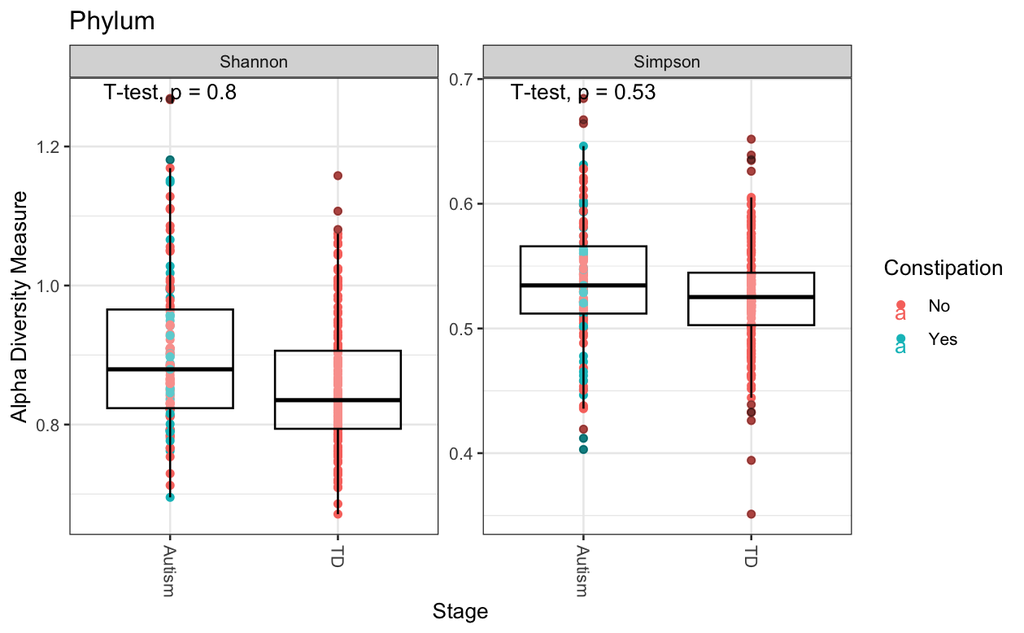

```r
plot_richness(PS_phylum, x="Stage", measures=c("Shannon", "Simpson"), color="Constipation") +
 geom_boxplot(alpha = 0.3, color = "black") +
  stat_compare_means(method = "t.test") + #ADD STATS
  theme(legend.position="right") +
  labs(title = "Phylum")
```

It would be nice to add in some statistics. But by eye it looks like the analyses could be similar.

Now I’ll try with just genus/phylum count:

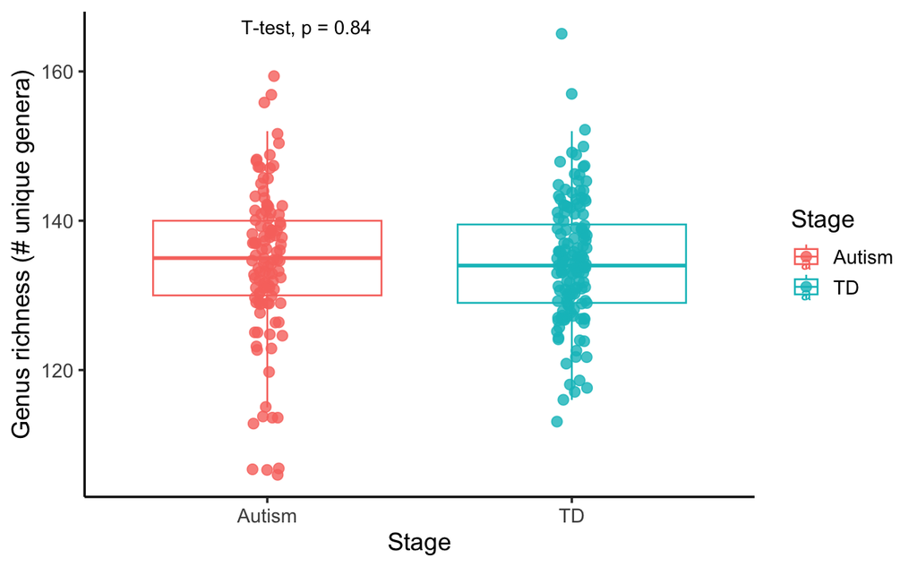

```r
# Extract OTU table
otu_table_genus <- as(otu_table(PS_genus), "matrix")
otu_table_phylum <- as(otu_table(PS_phylum), "matrix")

# Sum down columns → number of genera/phyla per sample
genus_richness <- colSums(otu_table_genus > 0)
phylum_richness <- colSums(otu_table_phylum > 0)

# Add Genus/PhylumRichness to sample_data(PS_genus)
sample_data(PS_genus)$GenusRichness <- genus_richness[sample_names(PS_genus)]
sample_data(PS_phylum)$PhylumRichness <- phylum_richness[sample_names(PS_phylum)]

# PLot
ggplot(sample_data(PS_genus), aes(x = Stage, y = GenusRichness, color = Stage)) +
  geom_boxplot(outlier.shape = NA) +
  stat_compare_means(method = "t.test") + #ADD STATS
  geom_jitter(width = 0.05, size = 2.5, alpha = 0.8) +
  labs(x = "Stage", y = "Genus richness (# unique genera)") +
  theme_classic(base_size = 14)
```

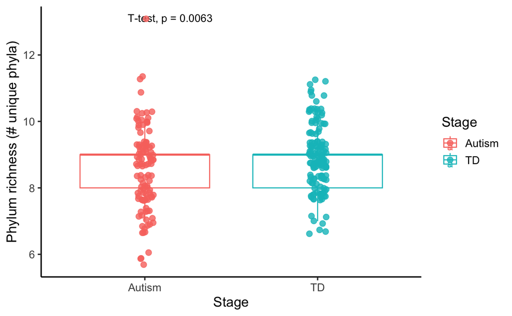

```r
ggplot(sample_data(PS_phylum), aes(x = Stage, y = PhylumRichness, color = Stage)) +
  geom_boxplot(outlier.shape = NA) +
  stat_compare_means(method = "t.test") + #ADD STATS
  geom_jitter(width = 0.05, size = 2.5, alpha = 0.8) +
  labs(x = "Stage", y = "Phylum richness (# unique phyla)") +
  theme_classic(base_size = 14)
```

Again these look like they could be similar to the author’s original figures just by eye, but I need to add statistical analysis to be sure. Now I’ll try to recreate the venn diagram they have of unique OTUs across groups.

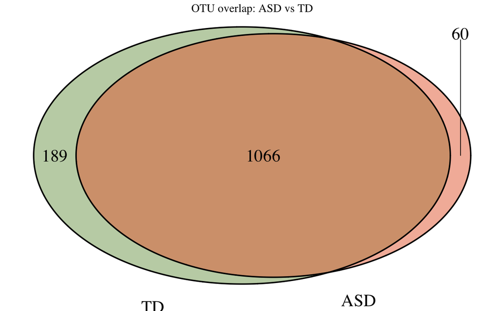

```r
library(VennDiagram)
library(grid)  # for grid.newpage()

# get list of OTUs from ASD and TD groups
ASD_OTUs <- otu_table_data %>%
  select(starts_with("B")) %>%
  filter(rowSums(. > 0) > 0) %>%
  rownames()

TD_OTUs <- otu_table_data %>%
  select(starts_with("A")) %>%
  filter(rowSums(. > 0) > 0) %>%
  rownames()

venn.plot <- venn.diagram(
  x = list(
    ASD = ASD_OTUs,
    TD    = TD_OTUs
  ),
  filename = NULL,  # draw to R graphics device instead of file
  #fill = c("#E8C2B1", "#C1CBB4"),
  fill = c("#E86A3C", "#7FA35A"),
  alpha = 0.5,
  cex = 1.5,
  cat.cex = 1.5,
  cat.pos = c(-20, 20),
  cat.dist = 0.05,
  main = "OTU overlap: ASD vs TD"
)

grid.newpage()
grid.draw(venn.plot)
```

This is not the same… While the number of total OTUs adds up to be the same as in the original figure, the subgroup totals are not the same. I am genuinely not sure why… It could be another artifact of rarification maybe?

Now I will construct a relative abundance stacked bar chart. They did not do this exact analysis, but I want it for comparison purposes with the metagenomic data. I am going to filter out rare and low abundance OTUs for easy viewing.

```r
# filter out rare and low abundant taxa
# Counts are already proportional (all samples have 31757)
PS_relabund  = transform_sample_counts(PS, function(x) x / sum(x) )
PS_relabund_genus  = transform_sample_counts(PS_genus, function(x) x / sum(x) )
PS_relabund_phylum  = transform_sample_counts(PS_phylum, function(x) x / sum(x) )
#Keep OTUs that are at least 1% of the relative abundance of each sample for at least (for 1 sample change to 0.003) (for 3 samples change to 0.01)
wh0 = genefilter_sample(PS_relabund, filterfun_sample(function(x) x > 0.01), A=0.003*nsamples(PS_relabund))
PS_relabund_filt = prune_taxa(wh0, PS_relabund)

wh1 = genefilter_sample(PS_relabund_genus, filterfun_sample(function(x) x > 0.01), A=0.003*nsamples(PS_relabund))
PS_relabund_filt_genus = prune_taxa(wh1, PS_relabund_genus)

wh2 = genefilter_sample(PS_relabund_phylum, filterfun_sample(function(x) x > 0.01), A=0.003*nsamples(PS_relabund))
PS_relabund_filt_phyla = prune_taxa(wh2, PS_relabund_phylum)
```

```r
# Check that taxa are filtered out
ntaxa(PS_relabund); ntaxa(PS_relabund_filt)
```

```
[1] 1322
[1] 165
```

[figure not shown]

```r
p<- plot_bar(PS_relabund_filt_genus, x = "Sample", y = "Abundance", fill = "Genus", facet_grid = "Stage")
p + geom_bar(aes(color=Genus, fill=Genus), stat="identity", position="stack") +
  theme_minimal()
```

```r
# Check that taxa are filtered out
ntaxa(PS_relabund); ntaxa(PS_relabund_filt)
```

```
[1] 1322
[1] 165
```

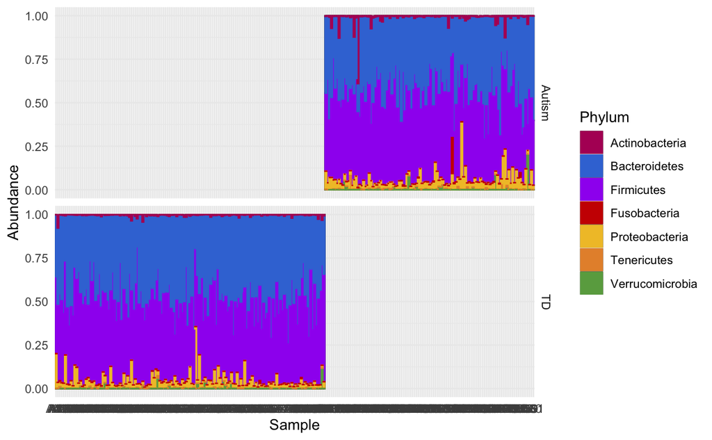

```r
phylum_colors <- c(
  "Actinobacteria"  = "#B31265",   # updated name for Actinomycetota
  "Verrucomicrobia" = "#6AA84F",
  "Bacteroidetes"   = "#3C78D8",
  "Proteobacteria"  = "#F1C232",
  "Firmicutes"      = "purple",
  "Fusobacteria"    = "#CC0000",
  "Tenericutes"     = "#E69138",
  "Lentisphaerae"   = "#0FA3B1",   # NEW — distinct teal for Lentisphaerae
  "ZBacteria_Other"  = "#999999"
)


p<- plot_bar(PS_relabund_filt_phyla, x = "Sample", y = "Abundance", fill = "Phylum", facet_grid = "Stage") +
  scale_color_manual(values = phylum_colors)
p + geom_bar(aes(color=Phylum, fill=Phylum), stat="identity", position="stack") +
  theme_minimal() +
  scale_fill_manual(values = phylum_colors) +
  scale_color_manual(values = phylum_colors)
```

Now I will try to recreate the PCoA analysis they performed. They use “unweighted unifract distance” but I am not sure how they did that without generating a taxonomic tree (this slot of my phyloseq is currently empty). I could try to make one from scratch - but for now I will just use bray curtis dissimilarity for my distance.

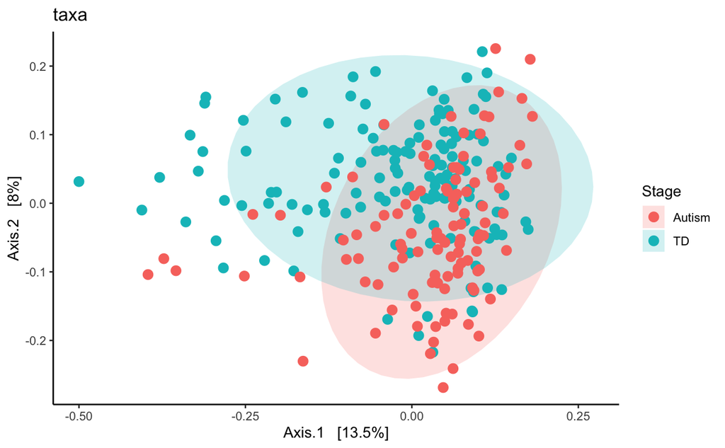

```r
PS_relabund_filt.ord <- ordinate(PS_relabund_filt, "PCoA")
PCoA1 = plot_ordination(PS_relabund_filt, PS_relabund_filt.ord, type="samples", color="Stage", title="taxa")
PCoA1 +
  stat_ellipse(aes(fill = Stage), geom = "polygon", alpha = 0.2, color = NA) +
  geom_point(size = 3) +
  theme_classic()
```

This looks pretty similar to the PCoA/Bray they did in their supplemental data. It is not the one they chose to display in their main figure because it is not as striking of a result. Regardless, you can see a bit more heterogeneity in the TD group and a bit more clustering in the Autism group. I would hesitate to say that the groups are truly separated, but the authors do not claim this either.

# Metagenomic Analysis

Rishi is working to re-process the metagenomic data using MetaSpades. This is not what they authors used… We don’t understand the analysis pipeline they claim to have used and they do a poor job of explaining it. Its not very reproducible :( <- sad face

While we are waiting for our data processed with a different pipeline, I will generate some figures from the metagenomic reads data table also provided by the authors on Kaggle (https://www.kaggle.com/datasets/antaresnyc/human-gut-microbiome-with-asd/data/discussion?select=ASD+meta+abundance.csv)

```r
#Read in metagenomic data table
metagenomic <- read.csv("/Users/cmdb/qb25-answers/DADA2_Subset_Attempt1_files/ASD meta abundance.csv", header = TRUE, check.names = FALSE)
# Identify sample columns (everything except Genus and Species columns)
sample_cols <- !(names(metagenomic) %in% c("Genus", "Species"))

#make sure values are all numeric
metagenomic[, sample_cols] <- lapply(metagenomic[, sample_cols], as.numeric)

#OTU matrix
otu_samples <- as.matrix(metagenomic[, sample_cols])

#create concatenated names to stand in for "OTU names"
rownames(otu_samples) <- make.unique(paste(metagenomic$Genus, metagenomic$Species, sep = "_"))
otu_metagenomic <- otu_table(otu_samples, taxa_are_rows = TRUE)

#Tax table (Genus + Species)
tax_tab <- as.matrix(metagenomic[, c("Genus", "Species")])
rownames(tax_tab) <- rownames(otu_samples)
colnames(tax_tab) <- c("Genus", "Species")

#Version as data frame
tax_tab_df <- as.data.frame(tax_tab, stringsAsFactors = FALSE)
```

I’ve cobbled together the pieces of a phyloseq object so we can use the same code to generate equavlent figures for the 16S and metagenomic data, but the OTU table we got from the authors only has Genus and Species calls (Thus I can not effectively compare phylum level diversity). I need to add the full taxonomy from the Genus/Species calls - To do that, I am going to try to piece together the rest of the taxonomy information from GTDB’s database of bacterial genomes.

```r
#Add Full Taxonomy from GTDB
GTDB <- read_tsv("/Users/cmdb/qb25-answers/DADA2_Subset_Attempt1_files/Figure_Attempt_files/bac120_taxonomy_r226.tsv",
                 col_names = c("genome", "taxonomy"))
GTDB <- GTDB %>%
  separate(
    taxonomy,
    into = c("Domain", "Phylum", "Class", "Order", "Family", "Genus", "Species"),
    sep = ";",
    fill = "right") %>%
  mutate(across(-genome,~ substr(.x, 4, nchar(.x)))) %>%
  select(-genome) %>%
  select(-Species) %>%
  distinct(Genus, .keep_all = TRUE) %>%
  filter(Genus %in% tax_tab_df$Genus) #only keep genera that are in tax_tab_df (my data)

#It looks like there are fungal genera in the data that are not in GTDB database - also some
#setdiff(unique(tax_tab_df$Genus), GTDB$Genus)

tax_tab_df <- tax_tab_df %>%
  left_join(GTDB, by = "Genus")
```

To try to get the remaining taxonomies (likely some fungal) I am going to use a tool (recommended by ChatGTP - but implemented through developer’s documentation) called “Taxize” to access NCBI’s taxonomy. This will also hopefully help with alternative taxonomies between databases.

```r
library(taxize)

missing_species <- filter(tax_tab_df, is.na(Domain))$Species

ncbi_IDs <- get_uid(missing_species, ask = FALSE)
```

[output not shown]

[output cut: 1152 more lines]

[output not shown]

```r
missing_taxonomies <- classification(ncbi_IDs, db = "ncbi")
```

```r
#These steps came from ChatGTP - I tried for hours to get the output of Taxize into a table.
#I also tried multiple other avenues but I got stuck and here we are


### 4. Convert classification() list → long data frame
classification_to_df <- function(x) {
  keep <- x[sapply(x, is.data.frame)]  # keep only valid entries
  out <- do.call(
    rbind,
    lapply(names(keep), function(id) {
      cbind(ncbi_id = id, keep[[id]], stringsAsFactors = FALSE)
    })
  )
  rownames(out) <- NULL
  out
}

missing_tax_long <- classification_to_df(missing_taxonomies)

### 5. Long → wide taxonomy table (one row per ncbi_id)
missing_tax_wide <- missing_tax_long %>%
  filter(rank %in% c("kingdom", "phylum", "class", "order",
                     "family", "genus", "species")) %>%
  distinct(ncbi_id, rank, .keep_all = TRUE) %>%
  select(ncbi_id, rank, name) %>%
  pivot_wider(
    names_from  = rank,
    values_from = name
  )

### 6. Map NCBI IDs back to the original Species vector
# (use missing_species, because names(ncbi_IDs) is empty)
id_map <- data.frame(
  Species = missing_species,
  ncbi_id = as.character(ncbi_IDs),
  stringsAsFactors = FALSE
)

### 7. Build final lookup table: Species + taxonomy
lookup_tax <- id_map %>%
  left_join(missing_tax_wide, by = "ncbi_id")

View(lookup_tax)
```

```r
#merging Taxize table with existing table
tax_tab_merged <- tax_tab_df %>%
  left_join(lookup_tax, by = "Species", suffix = c("", "_ncbi"))

tax_tab_filled <- tax_tab_merged %>%
  mutate(
    Domain  = ifelse(is.na(Domain),  kingdom, Domain),
    Phylum  = ifelse(is.na(Phylum),  phylum,  Phylum),
    Class   = ifelse(is.na(Class),   class,   Class),
    Order   = ifelse(is.na(Order),   order,   Order),
    Family  = ifelse(is.na(Family),  family,  Family),
    Genus   = ifelse(is.na(Genus),   genus,   Genus),
    Species = ifelse(is.na(Species), species, Species)
  ) %>%
  select(-kingdom, -phylum, -class, -order, -family, -genus, -species, -ncbi_id)

bacterial_phyla <- c(
  "Actinobacteria", "Actinomycetota",
  "Acidobacteriota", "Thermodesulfobacteriota",
  "Candidatus Cloacimonadota", "Candidatus Tectimicrobiota",
  "Lentisphaerota", "Kiritimatiellota",
  "Bdellovibrionota", "Candidatus Zixiibacteriota", "Atribacterota",
  "Ignavibacteriota", "Elusimicrobiota",
  "Candidatus Latescibacterota", "Nitrospinota",
  "Candidatus Omnitrophota", "Rhodothermota",
  "Aquificae", "Aquificota",
  "Bacillota", "Firmicutes",
  "Bacteroidetes", "Bacteroidota",
  "Campylobacterota",
  "Chlamydiae", "Chlamydiota",
  "Chlorobi", "Chlorobiota",
  "Chloroflexi", "Chloroflexota",
  "Cyanobacteria", "Cyanobacteriota",
  "Deferribacteres", "Deferribacterota",
  "Deinococcus-Thermus", "Deinococcota",
  "Fibrobacteres", "Fibrobacterota",
  "Fusobacteria", "Fusobacteriota",
  "Gemmatimonadetes", "Gemmatimonadota",
  "Mycoplasmatota", "Armatimonadota",
  "Nitrospirae", "Nitrospirota",
  "Planctomycetes", "Planctomycetota",
  "Proteobacteria", "Pseudomonadota",
  "Spirochaetes", "Spirochaetota",
  "Synergistetes", "Synergistota",
  "Thermotogae", "Thermotogota",
  "Verrucomicrobia", "Candidatus Melainabacteria",
  "Verrucomicrobiota", "Candidatus Margulisiibacteriota"
)

tax_tab_filled <- tax_tab_filled %>%
  mutate(
    Domain = ifelse(
      Phylum %in% bacterial_phyla,
      "Bacteria",
      Domain
    )
  ) %>%
  mutate(
    Domain = ifelse(
      is.na(Domain),
      "Bacteria",
      Domain
    )
  ) %>%
  mutate(
    Domain = ifelse(Species == "candidate division WOR_1 bacterium DG_54_3",
                    "Bacteria",
                    Domain)
  ) %>%
  mutate(
    Phylum = ifelse(Domain == "Bacteria" & is.na(Phylum),
                    "ZBacteria_Other",
                    Phylum)
  )

archaeal_phyla <- c(
  "Thermoplasmatota",
  "Methanobacteriota",
  "Microcaldota",
  "Nitrososphaerota",
  "Thermoproteota",
  "Candidatus Altarchaeota",
  "Candidatus Bathyarchaeota"
)

tax_tab_filled <- tax_tab_filled %>%
  mutate(
    Domain = ifelse(
      Phylum %in% archaeal_phyla,
      "Archaea",
      Domain
    )
  )

viral_phyla <- c(
  "Nucleocytoviricota",
  "Artverviricota",
  "Uroviricota",
  "Pisuviricota",
  "Preplasmiviricota",
  "Phixviricota",
  "Kitrinoviricota"
)

tax_tab_filled <- tax_tab_filled %>%
  mutate(
    Domain = ifelse(
      Phylum %in% viral_phyla,
      "Viruses",
      Domain
    )
  )

View(tax_tab_filled)
```

```r
tax_tab_filled <- tax_tab_filled %>%
  mutate(
    # Build OTU names as Genus_Species
    OTU = paste(Genus, Species, sep = "_"))
rownames(tax_tab_filled) <- tax_tab_filled$OTU

# Drop the OTU column
tax_tab_filled$OTU <- NULL

#Fix ordering problem
otu_ids <- taxa_names(otu_metagenomic)
tax_cols <- c("Domain", "Phylum", "Class", "Order", "Family", "Genus", "Species")
tax_taxonly <- tax_tab_filled[, tax_cols, drop = FALSE]
tax_for_phy <- tax_taxonly[otu_ids, , drop = FALSE]

#Add Taxonomy Table
tax_metagenomic <- tax_table(as.matrix(tax_for_phy))


#Add Sample metadata
meta_16s <- as(sample_data(PS), "data.frame")   # from your 16S object
meta_mg  <- meta_16s[colnames(otu_samples), , drop = FALSE]
samp_metagenomic <- sample_data(meta_mg)

#Build phyloseq object
PS_metagenomic <- phyloseq(otu_metagenomic, tax_metagenomic, samp_metagenomic)
```

Okay so now the metagenomic phyloseq object is built. Lets start with just a simple richness graph to prove it’s working.

```r
PS_metagenomic_genus <- tax_glom(PS_metagenomic, taxrank = "Genus")
PS_metagenomic_phylum <- tax_glom(PS_metagenomic, taxrank = "Phylum")
```

```r
theme_set(theme_bw())
plot_richness(PS_metagenomic, x="Stage", measures=c("Shannon", "Simpson"), color="Stage") +
  geom_boxplot(alpha = 0.3, color = "black") +
  stat_compare_means(method = "t.test") + #ADD STATS
  theme(legend.position="right") +
  labs(title = "Species")

plot_richness(PS_metagenomic_genus, x="Stage", measures=c("Shannon", "Simpson"), color="Stage") +
  geom_boxplot(alpha = 0.3, color = "black") +
  stat_compare_means(method = "t.test") + #ADD STATS
  theme(legend.position="right") +
  labs(title = "Genus")


plot_richness(PS_metagenomic_phylum, x="Stage", measures=c("Shannon", "Simpson"), color="Stage") +
 geom_boxplot(alpha = 0.3, color = "black") +
  stat_compare_means(method = "t.test") + #ADD STATS
  theme(legend.position="right") +
  labs(title = "Phylum")
```

[output not shown]

Lets make that venn diagram again:

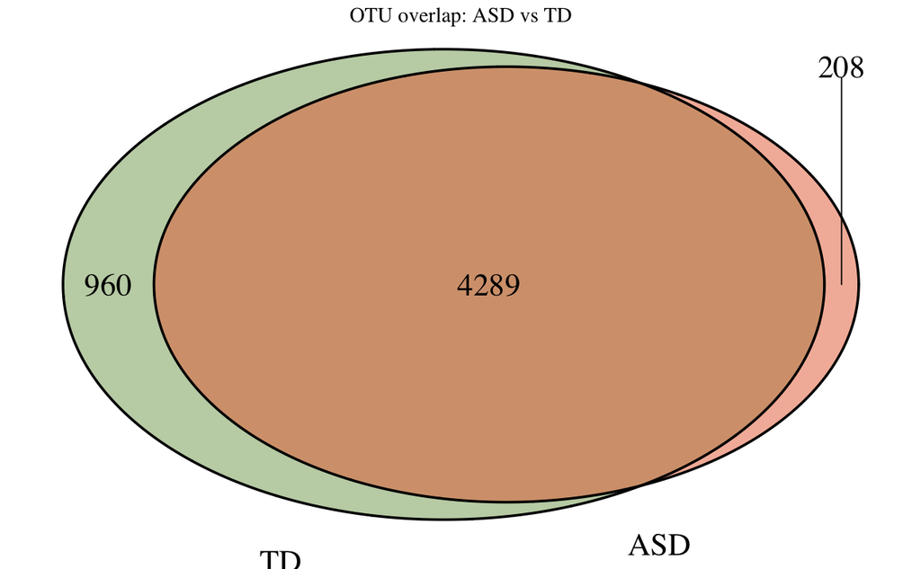

```r
# get list of OTUs from ASD and TD groups
ASD_OTUs_meta <- as.data.frame(otu_samples) %>%
  select(starts_with("B")) %>%
  filter(rowSums(. > 0) > 0) %>%
  rownames()

TD_OTUs_meta <- as.data.frame(otu_samples) %>%
  select(starts_with("A")) %>%
  filter(rowSums(. > 0) > 0) %>%
  rownames()

venn.plot <- venn.diagram(
  x = list(
    ASD = ASD_OTUs_meta,
    TD    = TD_OTUs_meta
  ),
  filename = NULL,  # draw to R graphics device instead of file
  #fill = c("#E8C2B1", "#C1CBB4"),
  fill = c("#E86A3C", "#7FA35A"),
  alpha = 0.5,
  cex = 1.5,
  cat.cex = 1.5,
  cat.pos = c(-20, 20),
  cat.dist = 0.05,
  main = "OTU overlap: ASD vs TD"
)

grid.newpage()
grid.draw(venn.plot)
```

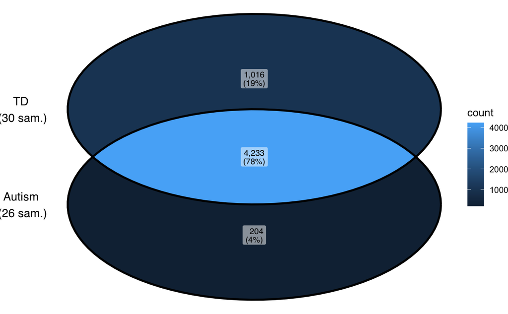

```r
ggvenn_pq(physeq = PS_metagenomic, fact = "Stage", type = "nb_taxa",
          set_name_size = 10,   # size of group labels
          label_size = 3) +     # size of intersection counts
  theme(text = element_text(hjust = 0.3)) +
  coord_cartesian(clip = "off")
```

```r
# filter out rare and low abundant taxa
# Counts are already proportional (all samples have 31757)
PS_meta_relabund  = transform_sample_counts(PS_metagenomic, function(x) x / sum(x) )
PS_meta_relabund_genus  = transform_sample_counts(PS_metagenomic_genus, function(x) x / sum(x) )
PS_meta_relabund_phylum  = transform_sample_counts(PS_metagenomic_phylum, function(x) x / sum(x) )
#Keep OTUs that are at least 1% of the relative abundance of each sample for at least (for 1 sample change to 0.003) (for 3 samples change to 0.01)
wh4 = genefilter_sample(PS_meta_relabund, filterfun_sample(function(x) x > 0.01), A=0.003*nsamples(PS_meta_relabund))
PS_meta_relabund_filt = prune_taxa(wh4, PS_meta_relabund)

wh5 = genefilter_sample(PS_meta_relabund_genus, filterfun_sample(function(x) x > 0.01), A=0.003*nsamples(PS_meta_relabund_genus))
PS_meta_relabund_filt_genus = prune_taxa(wh5, PS_meta_relabund_genus)

wh6 = genefilter_sample(PS_meta_relabund_phylum, filterfun_sample(function(x) x > 0.01), A=0.003*nsamples(PS_meta_relabund_phylum))
PS_meta_relabund_filt_phylum = prune_taxa(wh6, PS_meta_relabund_phylum)

# Check that taxa are filtered out
ntaxa(PS_meta_relabund); ntaxa(PS_meta_relabund_filt)
```

```
[1] 5619
[1] 110
```

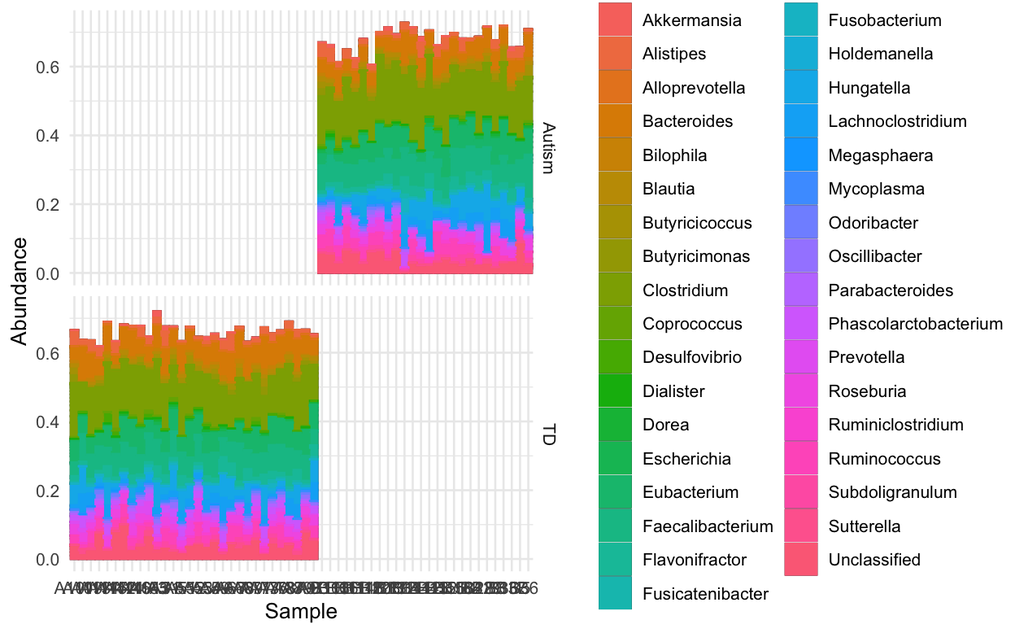

```r
p1<- plot_bar(PS_meta_relabund_filt, x = "Sample", y = "Abundance", fill = "Genus", facet_grid = "Stage")
p1 + geom_bar(aes(color=Genus, fill=Genus), stat="identity", position="stack") +
  theme_minimal()
```

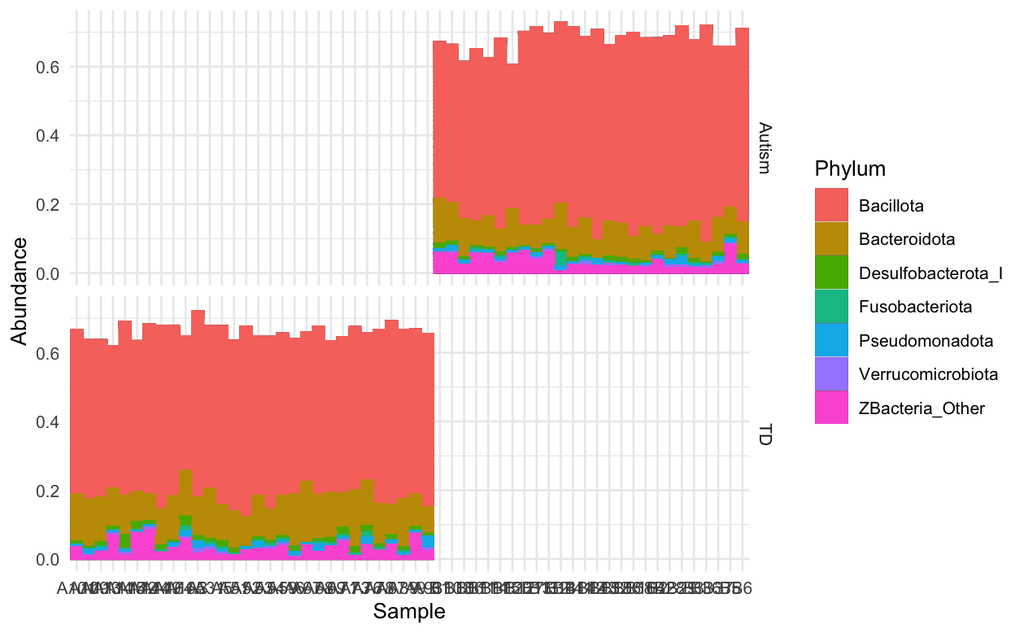

```r
p2<- plot_bar(PS_meta_relabund_filt, x = "Sample", y = "Abundance", fill = "Phylum", facet_grid = "Stage")
p2 + geom_bar(aes(color=Phylum, fill=Phylum), stat="identity", position="stack") +
  theme_minimal()
```

```r
NA
NA
```

These are using more updated taxonomies than the 16S data. For comparison I will have to “de-age” the metagenomic classifications so that our plots are comparable…

```r
#Extract taxonomy as a df
tax_meta <- as.data.frame(tax_table(PS_meta_relabund_filt_phylum))

#"De-age" meta names
tax_meta <- tax_meta %>%
  mutate(
    Phylum = case_when(
      Phylum == "Bacteroidota"       ~ "Bacteroidetes",
      Phylum == "Bacillota"          ~ "Firmicutes",
      Phylum == "Pseudomonadota"     ~ "Proteobacteria",
      Phylum == "Fusobacteriota"     ~ "Fusobacteria",
      Phylum == "Verrucomicrobiota"  ~ "Verrucomicrobia",
      Phylum == "Desulfobacterota_I" ~ "Proteobacteria",
      Phylum == "Actinomycetota" ~ "Actinobacteria",
      Phylum == "Lentisphaerota" ~ "Lentisphaerae",
      TRUE                           ~ Phylum
    )
  )

tax_table(PS_meta_relabund_filt_phylum) <- tax_table(as.matrix(tax_meta))

unique(as.data.frame(PS_meta_relabund_filt_phylum@tax_table)$Phylum)
```

```
[1] "Verrucomicrobia" "Bacteroidetes"   "Proteobacteria"  "Actinobacteria"  "Firmicutes"      "Fusobacteria"    "ZBacteria_Other"
[8] "Lentisphaerae"
```

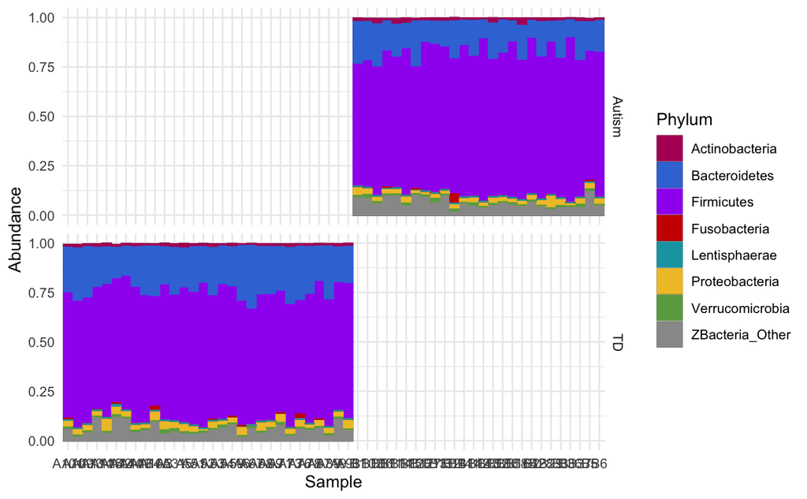

```r
p<- plot_bar(PS_meta_relabund_filt_phylum, x = "Sample", y = "Abundance", fill = "Phylum", facet_grid = "Stage") +
  scale_color_manual(values = phylum_colors)
p + geom_bar(aes(color=Phylum, fill=Phylum), stat="identity", position="stack") +
  theme_minimal() +
  scale_fill_manual(values = phylum_colors) +
  scale_color_manual(values = phylum_colors)
```

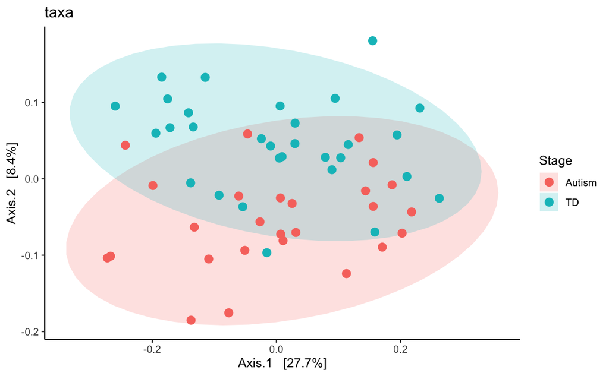

```r
PS_meta_relabund_filt.ord <- ordinate(PS_meta_relabund_filt, "PCoA")
PCoA2 = plot_ordination(PS_meta_relabund_filt, PS_meta_relabund_filt.ord, type="samples", color="Stage", title="taxa")
PCoA2 +
  stat_ellipse(aes(fill = Stage), geom = "polygon", alpha = 0.2, color = NA) +
  geom_point(size = 3) +
  theme_classic()
```